# Fuel Efficiency through Transmission Design: Hoax or Reality?

## DMDA Capstone

- Introduction
- Constraints
- Data Cleaning
- Univariate Exploration
- Bivariate Exploration
- Modeling
- Key Conclusions

# Introduction

**Data came from 2 files on the EPA website that detailed fuel economy from 2020-2021 vehicles driven in the United States.**  
2020 EPA Vehicle Dataset: https://www.epa.gov/sites/default/files/2021-03/20tstcar-2021-03-02.xlsx  
2021 EPA Vehicle Dataset: https://www.epa.gov/system/files/documents/2021-08/21tstcar-2021-08-25.xlsx

# Constraints for Vehicle Dataset

The data to be analyzed will be from the 2020 and 2021 EPA vehicle data set.

Unecessary columns will be removed from dataset to keep things clean.

If the values in the **adjusted fuel economy** is not a number, those records will be deleted. The main purpose of this research is to look at the relationship between transmission design and fuel economy. Visually, most of the NaN(not a number) values were from fully electric vehicles that did not get tested for fuel economy for some reason.

Analysis will be limited to vehicles that either run off of diesel, gasoline, or partial hybrid (combustion engine with battery power). All vehicles that are fully electric that do not run off of diesel or gasoline will be discarded.

Any extreme outlier values for adjusted fuel economy will be removed, as these are errors. Based on a visual inspection of all the data in the CSV file, I removed records where MPG is above 84.5 and below 8 mpg. Anything above 84.5 mpg was related to fully electric vehicles, and anything below about 8mpg is not a valid fuel economy value

A focus will be kept strictly on the relationship between transmission design (the number of gears in the transmission) and adjusted fuel economy.

# Import Modules

```python
import pandas as pd
import seaborn as sns
import numpy as np
import scipy.stats as stats
import statsmodels.api as sm
from matplotlib import pyplot as plt
from statsmodels.formula.api import ols
from sklearn import linear_model
from sklearn.metrics import r2_score

#Visualizaions plotted in the Notebook
%matplotlib inline
```

# Load data set

```python
# Assign both csv files to dataframes

df_1 = pd.read_csv('20tstcar-2021-03-02.csv')
df_2 = pd.read_csv('21tstcar-2021-08-25.csv')

# Combine data sets together
car_df = df_1.append(df_2, ignore_index = True)

# Output dataframe to a new CSV to check if dataframes were combined correctly.
# Verified files were correctly combined together by visual inspection.

car_df.to_csv(r'check_combined.csv', encoding='utf-8', index=False)
```

# Data Cleaning

```python
# Check the shape of dataframe. Verified both CSV files were combined. Total 67 columns, 8679 records.
car_df.shape
```

```
(8679, 67)
```

```python
# Show overview of dataframe
car_df.head(1)
```

|  | Model Year | Vehicle Manufacturer Name | Veh Mfr Code | Represented Test Veh Make | Represented Test Veh Model | Test Vehicle ID | Test Veh Configuration # | Test Veh Displacement (L) | Actual Tested Testgroup | Vehicle Type | ... | Set Coef A (lbf) | Set Coef B (lbf/mph) | Set Coef C (lbf/mph**2) | Aftertreatment Device Cd | Aftertreatment Device Desc | Police - Emergency Vehicle? | Averaging Group ID | Averaging Weighting Factor | Averaging Method Cd | Averging Method Desc |
| --- | --- | --- | --- | --- | --- | --- | --- | --- | --- | --- | --- | --- | --- | --- | --- | --- | --- | --- | --- | --- | --- |
| 0 | 2020 | aston martin | ASX | Aston Martin | DB11 | 500TT5148 | 0 | 5.2 | HASXV05.2AM5 | Car | ... | 6.81 | 0.0807 | 0.0245 | TWC | Three-way catalyst | N | NaN | NaN | N | No averaging |

1 rows × 67 columns

```python
# Review all column headings. Determine which ones to keep for research and which ones to drop.
car_df.info()
```

```
<class 'pandas.core.frame.DataFrame'>
RangeIndex: 8679 entries, 0 to 8678
Data columns (total 67 columns):
 #   Column                          Non-Null Count  Dtype
---  ------                          --------------  -----
 0   Model Year                      8679 non-null   int64
 1   Vehicle Manufacturer Name       8679 non-null   object
 2   Veh Mfr Code                    8679 non-null   object
 3   Represented Test Veh Make       8679 non-null   object
 4   Represented Test Veh Model      8679 non-null   object
 5   Test Vehicle ID                 8679 non-null   object
 6   Test Veh Configuration #        8679 non-null   int64
 7   Test Veh Displacement (L)       8679 non-null   float64
 8   Actual Tested Testgroup         8679 non-null   object
 9   Vehicle Type                    8679 non-null   object
```

[output cut: 59 more lines]

```python
# After reviewing column name data, removed the following columns by index.
car_df.drop(df_1.columns[[1,2,4,5,6,8,10,11,12,13,16,17,18,19,20,21,22,23,24,25,26,27,28,29,30,31,32,33,34,35,38,39,
           40,41,42,43,44,46,47,48,49,50,51,52,53,54,55,56,57,58,59,60,61,62,63,64,65,66]], axis=1, inplace=True)
```

```python
# Rename columns to make them more understandable.
car_df.rename(columns = {'RND_ADJ_FE':'Adjusted Fuel Economy'}, inplace = True)
car_df.rename(columns = {'# of Gears':'Number Gears'}, inplace = True)
```

```python
# Show the key columns for the current data analysis.
car_df.info()
```

```
<class 'pandas.core.frame.DataFrame'>
RangeIndex: 8679 entries, 0 to 8678
Data columns (total 9 columns):
 #   Column                      Non-Null Count  Dtype
---  ------                      --------------  -----
 0   Model Year                  8679 non-null   int64
 1   Represented Test Veh Make   8679 non-null   object
 2   Test Veh Displacement (L)   8679 non-null   float64
 3   Vehicle Type                8679 non-null   object
 4   Tested Transmission Type    8679 non-null   object
 5   Number Gears                8679 non-null   int64
 6   Test Fuel Type Description  8679 non-null   object
 7   Test Category               8679 non-null   object
 8   Adjusted Fuel Economy       8544 non-null   float64
dtypes: float64(2), int64(2), object(5)
memory usage: 610.4+ KB
```

### Columns of Interest - Variable Types

**Number Gears** - this is a **categorical** number with an ordinal value. Gears go from 1 speed to 10 speed. This will be the **independent** variable.

**Adjusted Fuel Economy** - gives **numerical** value of fuel economy for each vehicle tested; give in miles per gallon. This is a **continuous** variable and will be used as the **dependent** variable in any modeling

**Model Year** - discrete value, either 2020 or 2021

**Test Veh Displacement (L)** - this is numerical and relates to the size of the engine displacement. Usually, a normal combustion based engine will have an engine displacement of at least 1 liter (L) or higher.

**Test Fuel Type Description** - gives a description of the type of fuel used. This is used to filter out certain constraints.

**Test Category** - gives the type of vehicle test used by the EPA

</br>

```python
# Check to see overview of dataframe after some cleaning.
car_df.head(2)
```

|  | Model Year | Represented Test Veh Make | Test Veh Displacement (L) | Vehicle Type | Tested Transmission Type | Number Gears | Test Fuel Type Description | Test Category | Adjusted Fuel Economy |
| --- | --- | --- | --- | --- | --- | --- | --- | --- | --- |
| 0 | 2020 | Aston Martin | 5.2 | Car | Semi-Automatic | 8 | Tier 2 Cert Gasoline | FTP | 18.8 |
| 1 | 2020 | Aston Martin | 5.2 | Car | Semi-Automatic | 8 | Tier 2 Cert Gasoline | HWY | 30.9 |

```python
# Find if there are any missing values in columns (e.g., Not a Number (NaN))
car_df.isnull().sum()

# Remove rows with missing values in Adjusted Fuel Economy.
car_df.dropna(axis=0, subset=['Adjusted Fuel Economy'], inplace = True)
```

# Univariate Exploration

```python
car_df['Adjusted Fuel Economy'].describe()
```

```
count     8544.000000
mean        63.334059
std        521.383848
min          0.000000
25%         24.375000
50%         31.100000
75%         41.100000
max      10000.000000
Name: Adjusted Fuel Economy, dtype: float64
```

### Observation: Here we see there has to be an error with recording fuel economy because maximum value is 10,000 mpg. The mean is 63.3mpg and is too high because of the outliers (like 10,000 mpg).

```python
# See how many vehicles are from 2020 and from 2021.
car_df['Model Year'].value_counts().sort_index(ascending=False)
```

```
2021    4136
2020    4408
Name: Model Year, dtype: int64
```

### Observation: Both data sets have about 4,000 records.

```python
# See what types of vehicles are tested.
car_df['Vehicle Type'].value_counts().sort_index(ascending=False)
```

```
Truck    3039
Car      4449
Both     1056
Name: Vehicle Type, dtype: int64
```

### There were more cars being tested than trucks. However, upon visual inspection of the data set, the category "Both" could include things like convertible cars, minivans, smaller sport cars/crossover.

```python
car_df['Test Fuel Type Description'].value_counts().sort_index(ascending=False)
```

```
Tier 3 E10 Regular Gasoline (9 RVP @Low Alt.)       2
Tier 3 E10 Premium Gasoline (9 RVP @Low Alt.)      13
Tier 2 Cert Gasoline                             7412
Hydrogen 5                                         20
Federal Cert Diesel 7-15 PPM Sulfur               309
Electricity                                       233
E85 (85% Ethanol 15% EPA Unleaded Gasoline)       125
Cold CO Regular (Tier 2)                          271
Cold CO Premium (Tier 2)                          145
Cold CO E10 Premium Gasoline (Tier 3)               2
Cold CO Diesel 7-15 ppm Sulfur                      6
CARB LEV3 E10 Regular Gasoline                      6
Name: Test Fuel Type Description, dtype: int64
```

### Observation: Most vehicles tested would fall under the gasoline fuel type. There were a few hundred that were not liquid fuel types (electric, hydrogen).

```python
car_df['Test Category'].value_counts().sort_index(ascending=False)
```

```
US06     717
SC03     482
HWY     3295
FTP     3771
CD       279
Name: Test Category, dtype: int64
```

### Observation: These are types of tests that were performed. HWY represents testing under "highway" conditions. FTP represents testing more under "city" like driving conditions; FTP is "Federal Test Procedure." The SC03 test is related more to testing how fuel economy is impacted with the air conditioner is at high load and outside temperature is high. US06 relates to fuel economy at a higher speed, and with agressive driving. See: https://www.torquenews.com/2250/how-epa-determines-electric-vehicle-s-range-not-simple-it-sounds for more information. Also see the federal EPA regulations at: https://www.ecfr.gov/current/title-40/chapter-I/subchapter-U/part-1066 for more information.

```python
# See basic output of new dataframe
pd.set_option("display.max_rows", None)

# Let's check the list of manufacturers and how many vehicles were tested for each.
car_df['Represented Test Veh Make'].value_counts().sort_index(ascending=True)
```

```
ACURA                 57
AUDI                 379
Alfa Romeo            40
Aston Martin          22
BENTLEY               57
BMW                  680
BMX                   36
BUGATTI               14
BUICK                 66
BYD                    4
CADILLAC             188
CHEVROLET            617
Chrysler              37
Dodge                105
EPA                    2
Ferrari              112
Fiat                  20
Ford                 730
GMC                  169
Genesis               95
HONDA                496
HYUNDAI              273
Honda                 52
Hyundai              150
INFINITI             114
Jaguar                95
Jeep                 219
KIA                  183
Kandi                  2
Karma                 11
Kia                  178
LAMBORGHINI           53
LAND ROVER            23
LEXUS                372
Land Rover            99
Lincoln               77
Lotus                 30
MASERATI              12
MAZDA                156
MINI                  32
MITSUBISHI            68
Maserati              16
McLaren               24
Mercedes-Benz        368
Mini                  99
NISSAN               335
Pagani Automobili      2
Polestar              12
Porsche              240
RAM                  119
RUF                    2
Range Rover           17
Rolls Royce           28
Roush                 17
SUBARU               170
TOYOTA               634
Tesla                 84
Tesla Model 3          4
VOLKSWAGEN           158
Volkswagen             8
Volvo                 82
Name: Represented Test Veh Make, dtype: int64
```

### Observation: Appears that many manufacturers had many vehicles that were tested by the EPA, particularly manufactures like Toyota, Chevrolet, Ford, BMW, Honda, Audi, Hyundai, and Jeep.

```python
# What is the spread between the number of gears in the transmissions.
car_df['Number Gears'].value_counts().sort_index(ascending=True)
```

```
1     1612
2       26
4        2
5       60
6     1494
7     1015
8     2639
9      722
10     974
Name: Number Gears, dtype: int64
```

### Observation: There are quite a few transmissions that are 1 speed; these are considered continuous variable transmissions (CVT). CVT transmission have been gaining popularity over the years. Other than 1 speeds, 6 and 8 speeds make up the majority of the transmission design types.

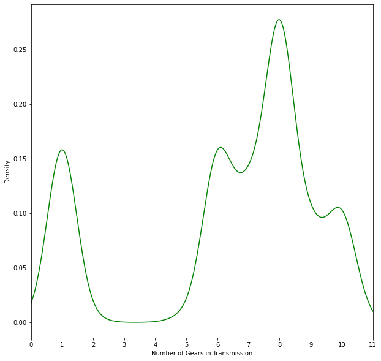

```python
# To see the relatinoship between the number of geaers in the transmission, plot a density graph.

plt.figure(figsize=(10,10))
car_df['Number Gears'].plot(kind='density', color='g')
plt.xlabel('Number of Gears in Transmission')
plt.xticks((0,1,2,3,4,5,6,7,8,9,10,11))
plt.xlim((0,11))
plt.show()
```

### Observation Transmissions with 1 speed and 6 speeds had about the same amount and there were more transmission with 8 speeds than any other type of transmission. An 8 speed transmission is the most popular design out of all the speeds.

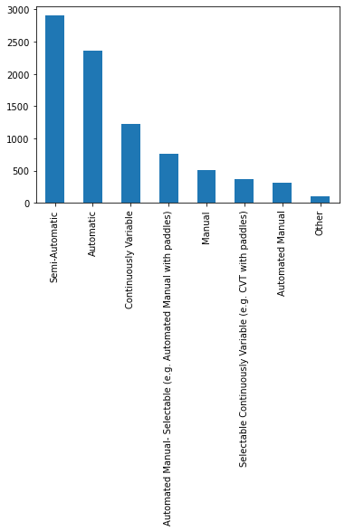

```python
# Shows what types of transmissions are in the data set
car_df['Tested Transmission Type'].value_counts().plot.bar()
plt.show()
```

### Observation: This is just to see what types of transmissions were tested. The EPA does not really give much information as to the nuances between these different types. Only about 500 out of about 8000 records are for the classic "manual" shift transmission. The rest are either "automatic" based transmissions or CVT based. Both of these typically will shift for you (automatically) or give you the ability to "shift gears" with things like paddles or other features.

## Adjusting Fuel Economy due to Outliers

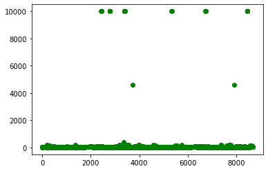

```python
# Check initial distribution of all adjusted fuel economy values. We see that there are a number of outlier values.
# Check for outliers for Adjusted fuel economy.
plt.scatter(x=car_df.index, y=car_df['Adjusted Fuel Economy'], color ='g')
plt.show()
```

### Observation: There are quite a few outliers that are way outside of the normal fuel economy range, like 10,000 miles per gallon!

```python
# Clean fuel economy values by processing with boolean masking.

# Step 1:
# Used boolean masking.  Keep any record that has a mpg of less than 84.5 mpg.
car_df = car_df[car_df['Adjusted Fuel Economy'] <= 84.5]

# Step 2:
# Keep any record that has a mpg greater than 8 mpg.
car_df = car_df[car_df['Adjusted Fuel Economy'] >= 8.0]

# Step 3:
# Keep records that are not related to having a full electric vehicle (See constraints section)
car_df = car_df[car_df['Test Fuel Type Description'] != 'Electricity']

# Step 4:
# Keep records that are not related to having a full electric vehicle (See constraints section)
car_df = car_df[car_df['Test Veh Displacement (L)'] > 1.00]
```

### Data Cleaning: Cut rows that have fuel economy values that are outliers. Visually inspected CSV dataset files. Any values over 84.5mpg were mainly related to full electric vehicles or other errors. Any fuel economy values less than 8mpg were also errors. For example, havinga fuel economy of 0 mpg is not feasible. Removed all records if fuel type was full electric.

```python
car_df.shape
```

```
(8239, 9)
```

```python
# Check statistics for fuel economy.
car_df[["Adjusted Fuel Economy"]].describe()
```

|  | Adjusted Fuel Economy |
| --- | --- |
| count | 8239.000000 |
| mean | 32.868127 |
| std | 12.011168 |
| min | 9.100000 |
| 25% | 24.200000 |
| 50% | 30.700000 |
| 75% | 40.200000 |
| max | 84.100000 |

### Observation: The values for fuel economy look like they are in better shape now, the min is 9.1 and the max is 84.1mpg.

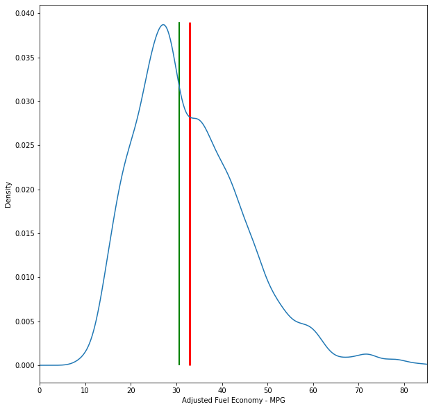

```python
# Density plot of Adjusted Fuel Economy
plt.figure(figsize=(10,10))

car_df['Adjusted Fuel Economy'].plot(kind='density')
plt.xlabel('Adjusted Fuel Economy - MPG')
plt.xlim((0,85))

# Red line is the mean line for Adjusted Fuel Economy
plt.vlines(car_df['Adjusted Fuel Economy'].mean(), ymin=0, ymax=0.039, linewidth=3, color='red')

# Green line is the median line for Adjusted Fuel Economy
plt.vlines(car_df['Adjusted Fuel Economy'].median(), ymin=0, ymax=0.039, linewidth=2.0, color="green")

plt.show()
```

### Observation: Distribution is Right skewed. The median line is less than the mean.

```python
# Check skewness to verify right skewed distribution. Verified.
car_df['Adjusted Fuel Economy'].skew()
```

```
0.8543090832435857
```

### Observation: Verified right skewed distribution since skew value is over 0.5. Skew value is less than 1 so the distribution does not have excessive skew.

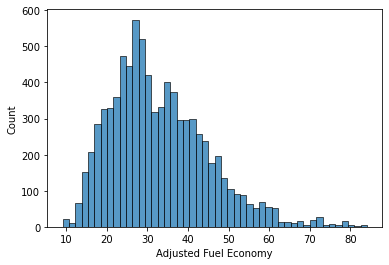

```python
# Plot histogram for Adjusted fuel economy before log transformation
sns.histplot(car_df['Adjusted Fuel Economy'])
plt.show()
```

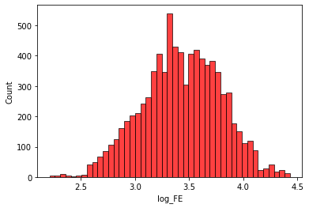

```python
# Performed log transformation and plot histogram to see if distribution is normalized.

# Created new column in dataframe to hold log of all Adjusted Fuel Economy values.
car_df['log_FE'] = np.log(car_df['Adjusted Fuel Economy'])

# Plotted log transformation fuel economy values
sns.histplot(car_df['log_FE'], color = 'red')
plt.show()
```

### Observation: Found that a log transformation did normalize the distribution of values for adjusted fuel economy.

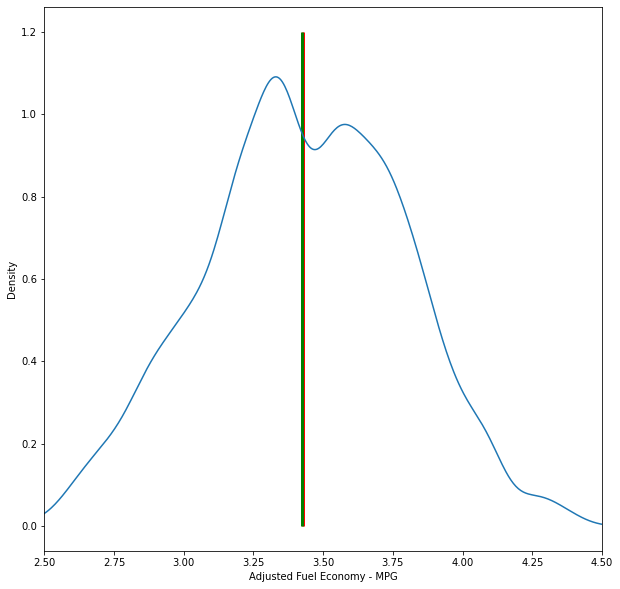

```python
# Density plot of the log adjusted - Fuel Economy
plt.figure(figsize=(10,10))
car_df['log_FE'].plot(kind='density')
plt.xlabel('Adjusted Fuel Economy - MPG')
plt.xlim((2.5,4.5))

# Red line is the mean for Adjusted Fuel Economy
plt.vlines(car_df['log_FE'].mean(), ymin=0, ymax=1.2, linewidth=3, color='red')

# Green line is the median for Adjusted Fuel Economy
plt.vlines(car_df['log_FE'].median(), ymin=0, ymax=1.2, linewidth=3, color="green")

plt.show()
```

### Observation: Log transformation helped the distribution of values where the mean and median are very close to the same value.

```python
# Check skewness to verify that log transformation improved distribution skewness. Yes it did.
car_df['log_FE'].skew()
```

```
-0.10914997490635081
```

```python
# What is the spread between the number of gears in the transmissions?
car_df['Number Gears'].value_counts().sort_index(ascending=True)
```

```
1     1374
4        2
5       60
6     1474
7     1003
8     2636
9      721
10     969
Name: Number Gears, dtype: int64
```

### Observation: 8 speed, 6 speed and 1 speed have the most number of vehicles tested.

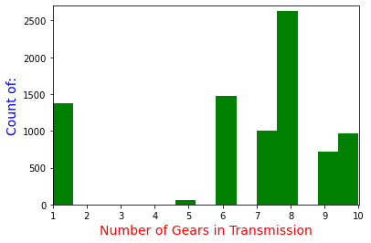

```python
# Lets plot a histogram showing the frequencies of each speed.

plt.hist(car_df['Number Gears'], bins=15, color='g')
plt.xlabel('Number of Gears in Transmission', size = 14, color ='r')
plt.ylabel('Count of:', size = 14, color = 'b')
plt.xlim((1,10))
plt.ylim((0,2700))
plt.show()
```

### Observation: After data cleaning, the observations are the same, 1 speed, 6 speed, and 8 speed make up the majority of transmission design. 7, 9, and 10 speeds also have significant values (approx 750-1000 records in the dataset).

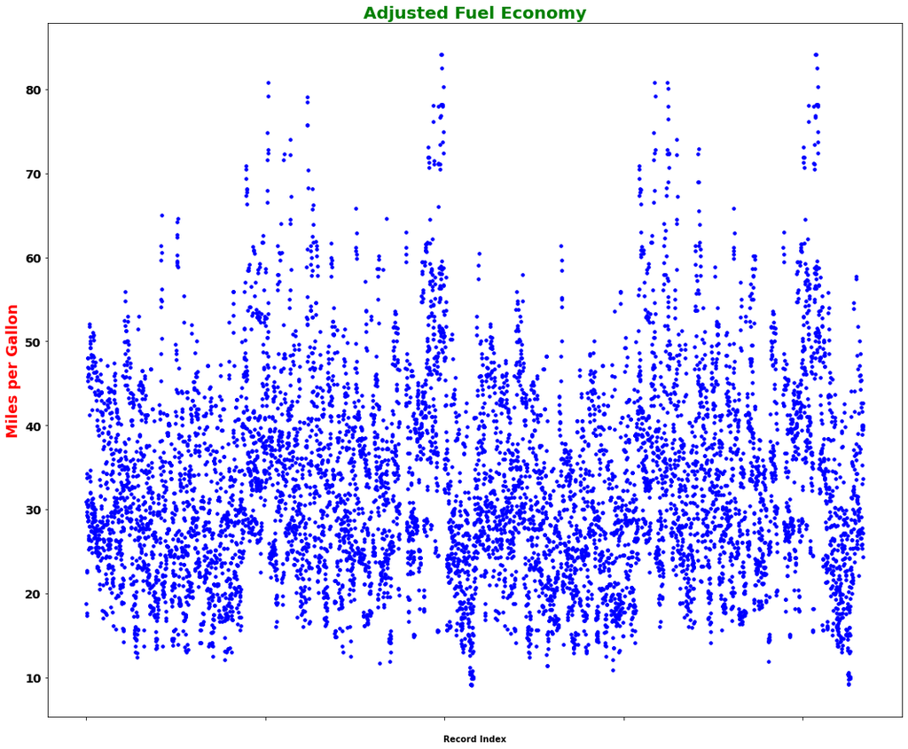

```python
# Make a scatter plot after all constraints applied to Adjusted Fuel Economy
plt.figure(figsize=(18,15))
plt.scatter(x=car_df.index, y=car_df['Adjusted Fuel Economy'], c='b', s=12)
plt.title("Adjusted Fuel Economy", loc = 'center', fontsize = 20, color = 'green', weight='bold')
plt.xlabel('Record Index', color = 'black', weight='bold')
plt.ylabel('Miles per Gallon', size = 'xx-large', color = 'red', weight='bold')
plt.yticks(fontsize=14, weight='bold')
plt.xticks(color='white')

plt.show()
```

### Observation: Most fuel economy values seem to fall between about 20 and 50 mpg.

# Bivariate Exploration

```python
## lets look at some summary statistics as it relates to the Number of Gears versus the Adjusted fuel economy
mpg_by_gear = car_df.groupby(['Number Gears'])[["Adjusted Fuel Economy"]].describe()
mpg_by_gear
```

| Number Gears | Adjusted Fuel Economy count | Adjusted Fuel Economy mean | Adjusted Fuel Economy std | Adjusted Fuel Economy min | Adjusted Fuel Economy 25% | Adjusted Fuel Economy 50% | Adjusted Fuel Economy 75% | Adjusted Fuel Economy max |
| --- | --- | --- | --- | --- | --- | --- | --- | --- |
| 1 | 1374.0 | 45.124090 | 12.587355 | 16.0 | 35.925 | 43.00 | 53.700 | 84.1 |
| 4 | 2.0 | 29.600000 | 8.909545 | 23.3 | 26.450 | 29.60 | 32.750 | 35.9 |
| 5 | 60.0 | 35.631667 | 13.724091 | 17.9 | 26.150 | 31.40 | 44.900 | 60.8 |
| 6 | 1474.0 | 33.538331 | 12.284610 | 10.9 | 24.500 | 31.55 | 41.075 | 80.8 |
| 7 | 1003.0 | 28.933699 | 10.493684 | 9.1 | 21.300 | 27.50 | 35.000 | 59.7 |
| 8 | 2636.0 | 30.288505 | 9.453875 | 10.7 | 23.300 | 28.70 | 36.300 | 64.6 |
| 9 | 721.0 | 30.815811 | 7.980535 | 15.7 | 24.200 | 28.90 | 37.600 | 50.8 |
| 10 | 969.0 | 26.922807 | 8.373606 | 12.5 | 20.300 | 25.50 | 33.500 | 50.2 |

### Observation: 1 speed transmission (CVT) has the highest mean fuel economy (FE). 8 speed transmission have the highest count and have more stable FE numbers (standard deviation is less).

# Look at any differences between FE and fuel type.

```python
# Sort fuel types and explore data
car_df['Test Fuel Type Description'].value_counts().sort_index(ascending=False)
```

```
Tier 2 Cert Gasoline                           7387
Federal Cert Diesel 7-15 PPM Sulfur             309
E85 (85% Ethanol 15% EPA Unleaded Gasoline)     125
Cold CO Regular (Tier 2)                        271
Cold CO Premium (Tier 2)                        141
Cold CO Diesel 7-15 ppm Sulfur                    6
Name: Test Fuel Type Description, dtype: int64
```

### Observation: Most vehicles tested were gasoline or gasoline blend while about 315 vehicles were diesel fuel type.

```python
#Remove diesel fuel types to look at all FE related to gasoline. Used boolean masking.

gasoline_df = car_df[(car_df['Test Fuel Type Description'] != 'Federal Cert Diesel 7-15 PPM Sulfur') &
                     (car_df['Test Fuel Type Description'] != 'Cold CO Diesel 7-15 ppm Sulfur')]
```

```python
# Removed gasoline fuel types to look at all FE related to diesel fuel. Used boolean masking.

diesel_df=car_df[(car_df['Test Fuel Type Description'] != 'Tier 2 Cert Gasoline') &
                 (car_df['Test Fuel Type Description'] != 'E85 (85% Ethanol 15% EPA Unleaded Gasoline)') &
                 (car_df['Test Fuel Type Description'] != 'Cold CO Regular (Tier 2)') &
                 (car_df['Test Fuel Type Description'] != 'Cold CO Premium (Tier 2)')]
```

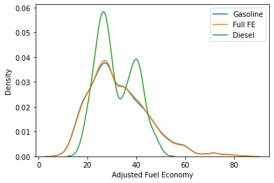

```python
# Plot density plots of FE by each transmisison design based on speed (e.g., 1 speed...10 speed)
fig, ax = plt.subplots()
plt.rcParams["figure.figsize"] = (15,10)
ax = sns.kdeplot(data=gasoline_df['Adjusted Fuel Economy'], label='Gasoline', ax=ax)
ax = sns.kdeplot(data=car_df['Adjusted Fuel Economy'], label='Full FE', ax=ax)
ax = sns.kdeplot(data=diesel_df['Adjusted Fuel Economy'], label='Diesel', ax=ax)
plt.legend()
plt.show()
```

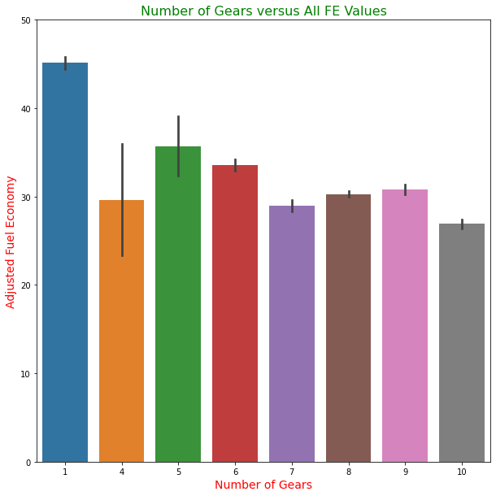

```python
# Set up plot to show bar graphs that categorize FE by transmission design (# of gears)

plt.figure(figsize=(10,10))
sns.barplot(data=car_df, x='Number Gears', y= 'Adjusted Fuel Economy')
plt.xlabel('Number of Gears',size=14, color='r')
plt.ylabel('Adjusted Fuel Economy',size=14, color='r')
plt.title('Number of Gears versus All FE Values', size=16, color='g')
plt.ylim((0,50))
plt.show()
```

### Observation: The bar graph illustrates that 1 speed transmission design (CVT) has the highest average FE followed by 5 speeds and 6 speeds. The general trend appears to be that as the number of gears increase in transmission design the fuel economy fluctuates. 5 speed FE values were high because there were only 60 vehicles that were tested.

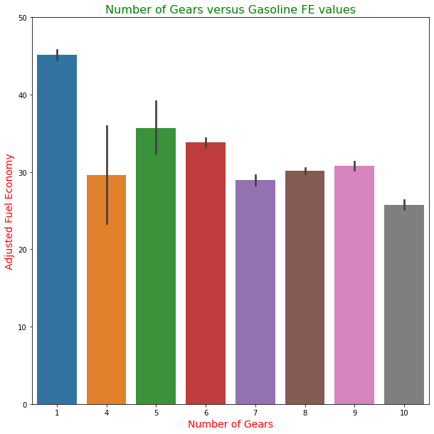

```python
# Show a barplot to capture FE data based on gasoline fuel type.

plt.figure(figsize=(10,10))
sns.barplot(data=gasoline_df, x='Number Gears', y= 'Adjusted Fuel Economy')
plt.xlabel('Number of Gears',size=14, color='r')
plt.ylabel('Adjusted Fuel Economy',size=14, color='r')
plt.title('Number of Gears versus Gasoline FE values', size=16, color='g')
plt.ylim((0,50))
plt.show()
```

### Observation: This looks fairly similar to the bar plot above with all the data together (diesel and gasoline fuel types)

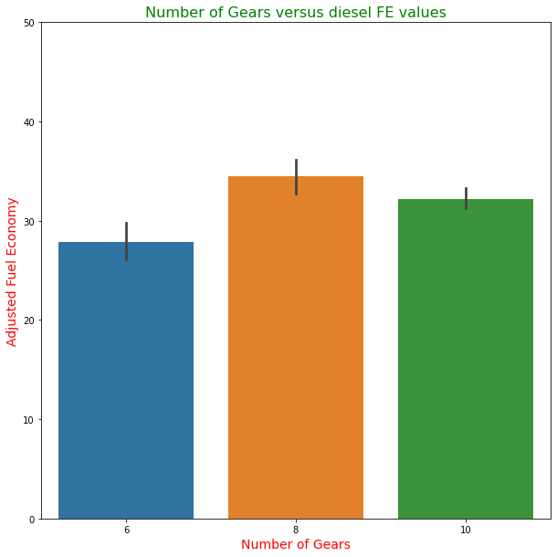

```python
# Show a barplot to capture FE data based on diesel fuel type.
plt.figure(figsize=(10,10))
sns.barplot(data=diesel_df, x='Number Gears', y= 'Adjusted Fuel Economy')
plt.xlabel('Number of Gears',size=14, color='r')
plt.ylabel('Adjusted Fuel Economy',size=14, color='r')
plt.title('Number of Gears versus diesel FE values', size=16, color='g')
plt.ylim((0,50))
plt.show()
```

### Observation: Notice that diesel fuel type vehicles only use 6, 8 or 10 speeds. The average mpg is around 30 or so. Due to the average mpg, it appears likely that most of the vehicles that are diesel are probably truck based. Smaller cars and Sport utility vehicles usually get 35mpg and up.

# Group FE data by Transmision Design (Gears)

```python
# Organize fuel economy data by groups according to the number of gears in transmission

chk_grps = car_df.groupby('Number Gears')
C1 = chk_grps.get_group(1)
C4 = chk_grps.get_group(4)
C5 = chk_grps.get_group(5)
C6 = chk_grps.get_group(6)
C7 = chk_grps.get_group(7)
C8 = chk_grps.get_group(8)
C9 = chk_grps.get_group(9)
C10= chk_grps.get_group(10)
```

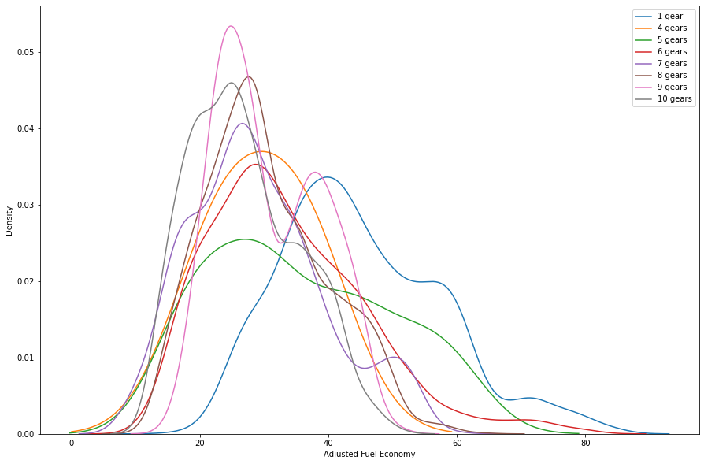

```python
# Plot density plots of FE by each transmisison design based on speed (e.g., 1 speed...10 speed)

fig, ax = plt.subplots()
plt.rcParams["figure.figsize"] = (15,10)
ax = sns.kdeplot(data = C1['Adjusted Fuel Economy'], label= '1 gear', ax=ax)
ax = sns.kdeplot(data = C4['Adjusted Fuel Economy'], label= '4 gears', ax=ax)
ax = sns.kdeplot(data = C5['Adjusted Fuel Economy'], label= '5 gears', ax=ax)
ax = sns.kdeplot(data = C6['Adjusted Fuel Economy'], label= '6 gears', ax=ax)
ax = sns.kdeplot(data = C7['Adjusted Fuel Economy'], label= '7 gears', ax=ax)
ax = sns.kdeplot(data = C8['Adjusted Fuel Economy'], label= '8 gears', ax=ax)
ax = sns.kdeplot(data = C9['Adjusted Fuel Economy'], label= '9 gears', ax=ax)
ax = sns.kdeplot(data = C10['Adjusted Fuel Economy'], label= '10 gears', ax=ax)
plt.legend()
plt.show()
```

```python
# Let's look at FE based on vehicle type.
mpg_by_veh_type = car_df.groupby(['Vehicle Type'])[["Adjusted Fuel Economy"]].describe()
mpg_by_veh_type
```

| Vehicle Type | Adjusted Fuel Economy count | Adjusted Fuel Economy mean | Adjusted Fuel Economy std | Adjusted Fuel Economy min | Adjusted Fuel Economy 25% | Adjusted Fuel Economy 50% | Adjusted Fuel Economy 75% | Adjusted Fuel Economy max |
| --- | --- | --- | --- | --- | --- | --- | --- | --- |
| Both | 1056.0 | 33.069697 | 9.073391 | 12.5 | 26.6 | 31.3 | 40.6 | 53.0 |
| Car | 4199.0 | 35.451608 | 13.662768 | 9.1 | 25.4 | 33.7 | 43.8 | 84.1 |
| Truck | 2984.0 | 29.161394 | 9.134751 | 10.9 | 22.2 | 27.8 | 35.7 | 65.0 |

### Observation: The statistics vary more with cars than the "both" or "Truck" category. The fuel economy values for cars have more variation between values.

```python
# Finally, let's take a look at FE grouped by vehicle manufacturer.
mpg_by_veh_make = car_df.groupby(['Represented Test Veh Make'])[["Adjusted Fuel Economy"]].describe()
mpg_by_veh_make
```

| Represented Test Veh Make | Adjusted Fuel Economy count | Adjusted Fuel Economy mean | Adjusted Fuel Economy std | Adjusted Fuel Economy min | Adjusted Fuel Economy 25% | Adjusted Fuel Economy 50% | Adjusted Fuel Economy 75% | Adjusted Fuel Economy max |
| --- | --- | --- | --- | --- | --- | --- | --- | --- |
| ACURA | 57.0 | 33.566667 | 7.871997 | 23.6 | 27.200 | 30.20 | 39.800 | 49.9 |
| AUDI | 368.0 | 26.580435 | 8.646979 | 13.0 | 20.100 | 25.40 | 30.200 | 50.9 |
| Alfa Romeo | 40.0 | 34.470000 | 8.074849 | 21.1 | 28.750 | 31.10 | 41.150 | 47.4 |
| Aston Martin | 22.0 | 25.368182 | 6.480402 | 16.9 | 18.800 | 23.95 | 30.825 | 34.3 |
| BENTLEY | 57.0 | 19.808772 | 5.702421 | 10.7 | 15.000 | 18.40 | 24.500 | 32.0 |
| BMW | 662.0 | 32.750453 | 8.663420 | 15.2 | 26.400 | 30.30 | 40.450 | 52.1 |
| BMX | 36.0 | 23.794444 | 6.269242 | 14.1 | 18.875 | 22.20 | 27.900 | 32.8 |
| BUGATTI | 14.0 | 12.592857 | 3.432080 | 9.2 | 10.400 | 10.60 | 14.700 | 18.2 |
| BUICK | 66.0 | 34.843939 | 7.636736 | 22.7 | 27.600 | 32.35 | 42.850 | 48.6 |
| CADILLAC | 188.0 | 27.621277 | 9.249609 | 14.1 | 21.625 | 26.65 | 35.450 | 50.0 |
| CHEVROLET | 613.0 | 27.353344 | 9.553127 | 10.9 | 19.600 | 25.40 | 33.600 | 55.9 |
| Chrysler | 37.0 | 33.781081 | 8.854153 | 18.1 | 24.300 | 35.00 | 42.500 | 43.7 |
| Dodge | 105.0 | 22.860952 | 8.166059 | 12.4 | 15.700 | 19.80 | 28.800 | 43.1 |
| EPA | 2.0 | 56.350000 | 2.192031 | 54.8 | 55.575 | 56.35 | 57.125 | 57.9 |
| Ferrari | 112.0 | 21.501786 | 5.581985 | 11.4 | 17.350 | 20.50 | 26.250 | 34.6 |
| Fiat | 20.0 | 36.550000 | 8.691345 | 27.0 | 29.700 | 32.55 | 44.425 | 53.0 |
| Ford | 697.0 | 28.414060 | 9.978768 | 12.9 | 21.100 | 26.00 | 34.300 | 65.0 |
| GMC | 169.0 | 27.621893 | 8.123397 | 14.1 | 20.500 | 26.30 | 32.100 | 44.5 |
| Genesis | 95.0 | 28.364211 | 7.840510 | 16.1 | 22.550 | 26.70 | 34.750 | 47.5 |
| HONDA | 492.0 | 41.466667 | 12.585761 | 21.9 | 33.250 | 38.60 | 48.600 | 80.8 |
| HYUNDAI | 267.0 | 44.420599 | 13.819763 | 18.7 | 33.600 | 42.10 | 52.000 | 80.8 |
| Honda | 52.0 | 35.350000 | 8.327382 | 22.5 | 28.000 | 33.45 | 39.700 | 53.3 |
| Hyundai | 138.0 | 32.576087 | 8.352407 | 18.8 | 25.900 | 29.20 | 38.400 | 56.1 |
| INFINITI | 114.0 | 29.803509 | 8.039107 | 16.2 | 24.200 | 27.15 | 37.525 | 43.8 |
| Jaguar | 83.0 | 32.695181 | 8.456732 | 17.2 | 26.350 | 30.70 | 38.050 | 49.6 |
| Jeep | 219.0 | 31.399087 | 7.988484 | 13.7 | 25.000 | 28.70 | 38.150 | 46.5 |
| KIA | 179.0 | 40.096089 | 14.865254 | 16.5 | 27.000 | 40.50 | 53.300 | 72.9 |
| Karma | 11.0 | 28.263636 | 7.079304 | 16.0 | 23.700 | 30.80 | 32.700 | 37.6 |
| Kia | 170.0 | 34.468824 | 8.337165 | 20.1 | 27.250 | 34.10 | 39.950 | 57.2 |
| LAMBORGHINI | 53.0 | 15.390566 | 4.603354 | 9.1 | 10.400 | 15.00 | 18.500 | 24.2 |
| LAND ROVER | 23.0 | 23.882609 | 5.068409 | 18.5 | 19.200 | 22.30 | 28.400 | 33.7 |
| LEXUS | 370.0 | 35.281892 | 10.352449 | 14.8 | 27.250 | 36.40 | 42.400 | 63.0 |
| Land Rover | 93.0 | 26.196774 | 6.911592 | 16.1 | 20.300 | 25.50 | 30.800 | 40.3 |
| Lincoln | 77.0 | 31.696104 | 8.857727 | 19.4 | 26.800 | 30.60 | 38.700 | 52.0 |
| Lotus | 30.0 | 22.730000 | 6.050372 | 16.2 | 18.750 | 20.30 | 24.775 | 34.7 |
| MASERATI | 12.0 | 24.700000 | 6.537166 | 16.7 | 19.200 | 22.95 | 30.725 | 33.5 |
| MAZDA | 156.0 | 40.700641 | 8.815108 | 25.6 | 32.975 | 41.00 | 47.400 | 61.7 |
| MINI | 32.0 | 39.109375 | 8.282915 | 27.3 | 31.025 | 40.55 | 46.275 | 51.3 |
| MITSUBISHI | 66.0 | 41.628788 | 11.988491 | 20.1 | 31.300 | 41.20 | 46.800 | 65.8 |
| Maserati | 16.0 | 22.906250 | 6.815225 | 14.1 | 17.425 | 20.60 | 28.000 | 34.8 |
| McLaren | 19.0 | 20.600000 | 5.756060 | 14.8 | 15.350 | 19.00 | 24.250 | 30.1 |
| Mercedes-Benz | 367.0 | 30.378474 | 8.861222 | 12.5 | 23.650 | 28.90 | 37.350 | 52.1 |
| Mini | 99.0 | 41.257576 | 8.494333 | 28.4 | 33.800 | 37.80 | 49.250 | 55.9 |
| NISSAN | 311.0 | 33.971383 | 11.935798 | 16.4 | 23.700 | 33.90 | 41.400 | 60.2 |
| Pagani Automobili | 2.0 | 16.400000 | 6.646804 | 11.7 | 14.050 | 16.40 | 18.750 | 21.1 |
| Polestar | 10.0 | 29.100000 | 5.220473 | 22.1 | 27.500 | 28.70 | 29.700 | 37.5 |
| Porsche | 213.0 | 28.245540 | 6.680148 | 18.2 | 23.000 | 27.20 | 33.500 | 64.6 |
| RAM | 119.0 | 28.971429 | 8.443191 | 12.7 | 21.050 | 28.70 | 33.300 | 48.2 |
| Range Rover | 17.0 | 29.964706 | 6.710062 | 22.7 | 24.700 | 25.20 | 37.100 | 39.9 |
| Rolls Royce | 28.0 | 19.510714 | 5.803469 | 11.9 | 14.300 | 17.35 | 25.500 | 27.5 |
| Roush | 14.0 | 19.321429 | 5.222905 | 13.0 | 14.650 | 18.20 | 24.975 | 26.2 |
| SUBARU | 170.0 | 37.954706 | 9.267076 | 19.8 | 30.325 | 36.45 | 47.200 | 53.6 |
| TOYOTA | 619.0 | 44.087399 | 15.515922 | 15.4 | 33.650 | 44.50 | 53.700 | 84.1 |
| VOLKSWAGEN | 158.0 | 32.415190 | 8.984191 | 20.0 | 26.300 | 30.45 | 36.275 | 60.5 |
| Volvo | 80.0 | 36.351250 | 7.870486 | 22.0 | 27.575 | 37.55 | 42.700 | 50.1 |

### Observation: The higher the count of vehicles tested, the better chance that the fuel economy values are close to the mean (approximately 30mpg). Although, there are some anomlies, like Toyota.

## Further Bivariate Exploration with Correlation

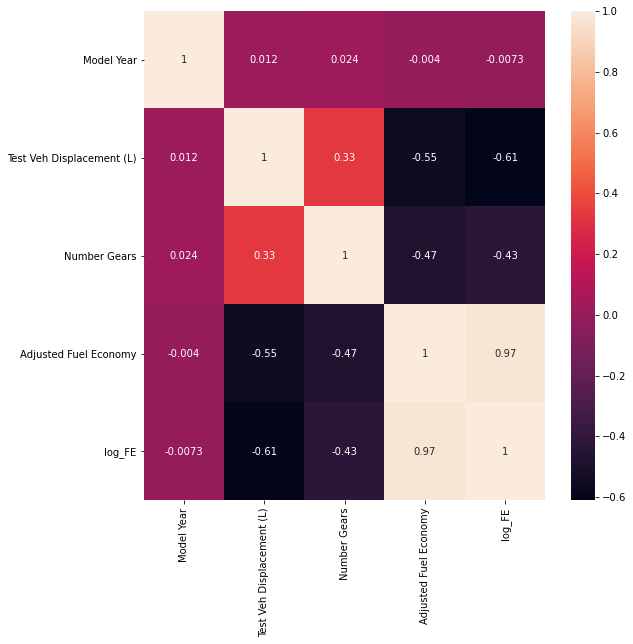

```python
plt.figure(figsize=(9,9))
corrMatrix = car_df.corr()
sns.heatmap(corrMatrix, annot=True)
plt.show()
```

### Observation: There is a good amount of negative correlation between the number of gears and adjusted FE.

## Looking for outliers given Number of Gears vs. Adjusted FE

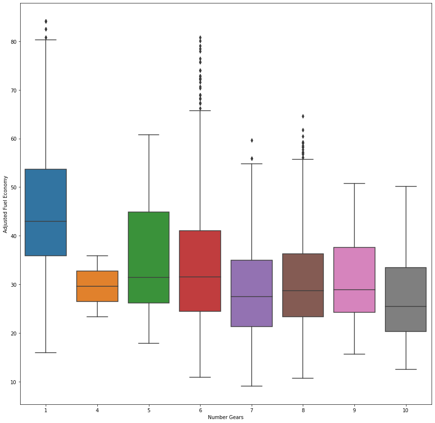

```python
# Boxplot to show if some of the MPG values are on the outer edge. Shows right skewed*
plt.figure(figsize=(15,15))
sns.boxplot(y=car_df['Adjusted Fuel Economy'], x = car_df['Number Gears'])
plt.show()
```

### Observation: lot of outliers for 6 speed transmission; this makes the mean higher that it probably should be. 6 speed and 8 speed transmissions are probably fairly close to the overall mean of the distribution.

# Modeling

## Model 1: Linear Regression Model

```python
# Set up variables for linear regression model
X=pd.DataFrame(car_df['Number Gears'])
y=pd.DataFrame(car_df['Adjusted Fuel Economy'])

# Set up linear regression model and use fit function
linear_regress = linear_model.LinearRegression().fit(X,y)

print('Intercept for linear model: ', linear_regress.intercept_)
print('Slope for model: ', linear_regress.coef_)
print('R-squared value: ', linear_regress.score(X, y))
```

```
Intercept for linear model:  [46.22475993]
Slope for model:  [[-2.00761297]]
R-squared value:  0.21855277411283514
```

### Observation: Using the y=mx+b formula, we have a linear regression line of y = -2.01x + 46.22. When x value is set to zero, y intercept is 46.22. Slope coefficient is a negative number. According to R squared, 22% of the variance can be explained by the Number of Gears in the transmission design.

```python
# Find residual values of the linear model
train_predict = linear_regress.predict(X)
residual_values = pd.DataFrame(car_df['Adjusted Fuel Economy']) - train_predict
residual_values.describe()
```

|  | Adjusted Fuel Economy |
| --- | --- |
| count | 8.239000e+03 |
| mean | 6.787197e-16 |
| std | 1.061781e+01 |
| min | -2.821715e+01 |
| 25% | -7.417147e+00 |
| 50% | -1.517147e+00 |
| 75% | 6.947563e+00 |
| max | 4.662092e+01 |

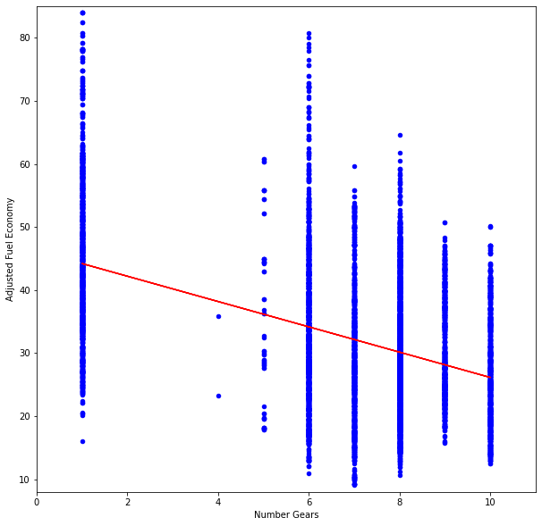

```python
# Scatter plot with the regression line plotted.
car_df.plot(kind="scatter", x='Number Gears', y='Adjusted Fuel Economy',
            figsize=(10,10), color='blue', xlim=(0,11), ylim=(8,85))
plt.plot(car_df['Number Gears'], train_predict, color = 'red')
plt.show()
```

### Observation: As the number of gears increases, the linear regression model shows that the average FE does decrease in value.

## Model 2: Ordinary Least Squares Model

```python
# Set up OLS model
Fuel = np.array(car_df['Adjusted Fuel Economy'])
Gear = np.array(car_df['Number Gears'])

# Add constant to the Number of Gears so that statsmodel will calculate the intercept
Gear = sm.add_constant(Gear)
modelL=sm.OLS(Fuel,Gear)

# Monitor results from OLS model
resultsL=modelL.fit()
```

```python
# Give a detailed summary of the OLS model.
resultsL.summary()
```

OLS Regression Results

| Dep. Variable: | y | R-squared: | 0.219 |
| --- | --- | --- | --- |
| Model: | OLS | Adj. R-squared: | 0.218 |
| Method: | Least Squares | F-statistic: | 2304. |
| Date: | Sun, 31 Oct 2021 | Prob (F-statistic): | 0.00 |
| Time: | 13:33:45 | Log-Likelihood: | -31155. |
| No. Observations: | 8239 | AIC: | 6.231e+04 |
| Df Residuals: | 8237 | BIC: | 6.233e+04 |
| Df Model: | 1 |  |  |
| Covariance Type: | nonrobust |  |  |

|  | coef | std err | t | P>\|t\| | [0.025 | 0.975] |
| --- | --- | --- | --- | --- | --- | --- |
| const | 46.2248 | 0.302 | 153.128 | 0.000 | 45.633 | 46.817 |
| x1 | -2.0076 | 0.042 | -47.997 | 0.000 | -2.090 | -1.926 |

| Omnibus: | 430.729 | Durbin-Watson: | 1.256 |
| --- | --- | --- | --- |
| Prob(Omnibus): | 0.000 | Jarque-Bera (JB): | 501.534 |
| Skew: | 0.580 | Prob(JB): | 1.24e-109 |
| Kurtosis: | 3.338 | Cond. No. | 18.9 |

Notes:  
[1] Standard Errors assume that the covariance matrix of the errors is correctly specified.

### Observation: The linear equation from the Ordinary Least Squares modeling (OLS) is the same as the linear regression model above. The equation is still y = -2.01x + 46.22. R squared value is 0.219.

## Model 3: Kruskal Wallis Test

### Kruskal Wallis test is used for comparing sets of data grouped by category. In this case we have continuous FE data that can be categorized by transmission design (from 1 speed to 10 speeds).

```python
# Create FE in groups based on transmisison design (Gears). Use a numpy array to hold FE values based on gearing.

# G1 represents FE values for 1 speed transmissions, G4 represents FE values for 4 speed transmission, and so on.

G1 = C1["Adjusted Fuel Economy"].to_numpy()
G4 = C4["Adjusted Fuel Economy"].to_numpy()
G5 = C5["Adjusted Fuel Economy"].to_numpy()
G6 = C6["Adjusted Fuel Economy"].to_numpy()
G7 = C7["Adjusted Fuel Economy"].to_numpy()
G8 = C8["Adjusted Fuel Economy"].to_numpy()
G9 = C9["Adjusted Fuel Economy"].to_numpy()
G10 = C10["Adjusted Fuel Economy"].to_numpy()
```

```python
# Since FE values can be grouped by the category gear, perform a one-way ANOVA test using Kruskal-Wallis Test.

# Compared all grouped categories, output p-value.
stats.kruskal(G1, G4, G5, G6, G7, G8, G9, G10)
```

```
KruskalResult(statistic=1626.8984988456568, pvalue=0.0)
```

```python
# To verify that all p values are not 0, compare 4 speed and 1 speed transmissions, output p-value.
stats.kruskal(G4, G1)
```

```
KruskalResult(statistic=3.335100397682966, pvalue=0.06781626795126895)
```

```python
# Check another grouping.
# Compare 4 speed, 7 speed, and 10 speed transmissions, output p-value
stats.kruskal(G4, G7, G10)
```

```
KruskalResult(statistic=13.932502237924503, pvalue=0.0009431821640480639)
```

### Observation: The Kruskal Wallis test has p value of 0 when taking all groups into consideration.

## Model 4: Polynomial line plot model

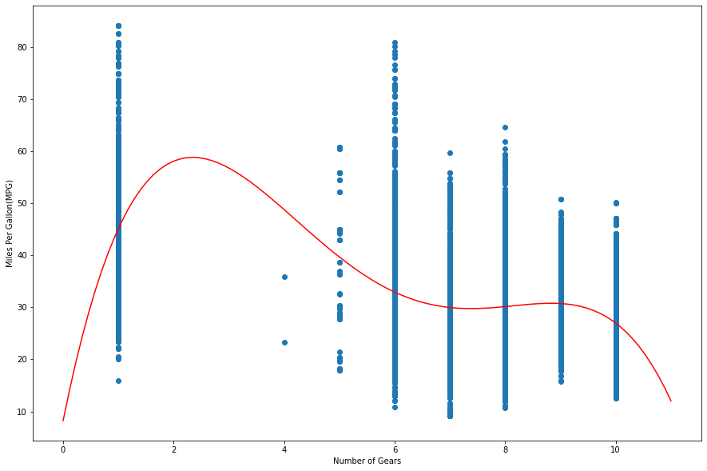

```python
# Create array for x-axis that just represents the transmission design (Gear) values.
NumG = np.array(car_df['Number Gears'])

# Fuel variable was created earlier as a numpy array to hold all relevant FE values.
# Make a polynomial using the polynomial line plot tool in Python
modelP = np.poly1d(np.polyfit(NumG, Fuel, 4))  # 4th order polynomial yielded the best results, guess and check.

# Give parameters of how to disply the line we start at 0, and end at 11 for x axis, and y-axis goes to 95.
line = np.linspace(0, 11, 95)

# Create the scatter plot for Gears versus FE.
plt.scatter(NumG, Fuel)

#Draw the modeled line of polynomial:
plt.plot(line, modelP(line), color='r')
plt.ylabel('Miles Per Gallon(MPG)')
plt.xlabel('Number of Gears')
plt.show()
```

```python
# Find r squared value of polynomial model
print('R sqaured score is: ', r2_score(Fuel, modelP(NumG)))
```

```
R sqaured score is:  0.23095379121376125
```

### Observation: 4th degree polynomial. The r squared value is not much better 0.23 versus 0.219.

# Key Conclusions

### Research Question:

To what extent do the total number of gears in the transmission have on fuel economy (FE) for vehicles driven in the United States that were produced from 2020-2021?</u>

## Key conclusions based on Data Analysis:

There were about as many 2020 models tested as there were 2021 models.

8 speed transmissions were the most popular.

Most FE values were between 15 and 50 mpg for all vehicles tested.

6 speed and 8 speed transmissions do have some outlier values.

There is a negative correlation between transmission design and FE.

Slope coefficient was negative for the linear equation model.

Accept alternative hypothesis: there is an impact between transmission design and FE.

## Key conclusions for Legend's Business Needs:

There is an impact between transmission design and FE.

Given FE and popularity of use, 1 speed CVT transmissions are suited well for improving FE in the Alanty model; this is especially due to their lightweight design and reduced cost.

8 speed transmissions provide stable FE numbers and are built for stable FE.

5 speed transmissions had good FE numbers but sample size was too low, 60.

6 speed transmissions had good FE numbers but had a number of outliers which inflated average mpg values.

Performing further analysis would be beneficial to see if a CVT transmission would be beneficial for FE and customer satisfaction.